# Лабораторная работа №9

Настройка POP3/IMAP сервера

Цыкунова Екатерина Михайловна

1132246732@rudn.ru

Российский университет дружбы народов

2026-10-21

# Цели и задачи работы

## Цель лабораторной работы

Целью данной работы является приобретение практических навыков установки и настройки почтового сервера Dovecot, организации получения электронной почты по протоколам POP3 и IMAP, настройки почтового клиента Evolution, проверки работы почтовых служб и автоматизации конфигурации с помощью Vagrant.

## Задачи лабораторной работы

- установить Dovecot и Telnet на виртуальной машине `server`;
- настроить протоколы IMAP и POP3, аутентификацию пользователей и расположение почтовых ящиков;
- настроить взаимодействие Dovecot с Postfix и межсетевой экран;
- установить и настроить почтовый клиент Evolution на виртуальной машине `client`;
- проверить отправку и получение электронных сообщений;
- проверить работу почтовой службы с помощью Telnet, `mail` и `doveadm`;

# Процесс выполнения лабораторной работы

## Устанавливаю Dovecot и Telnet

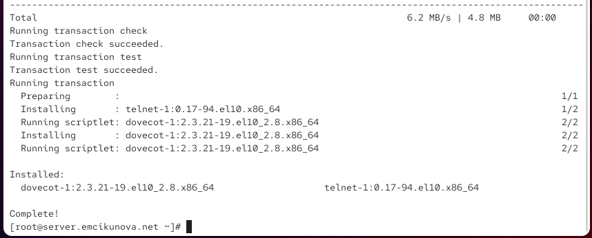

Установка почтового сервера Dovecot и утилиты Telnet на виртуальной машине server

## Настраиваю почтовые протоколы Dovecot

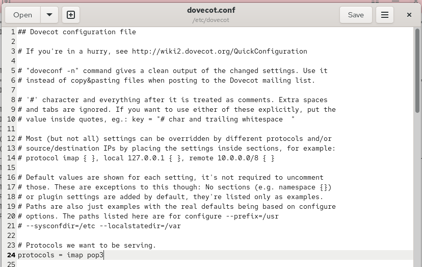

Настройка протоколов IMAP и POP3 в конфигурационном файле dovecot.conf

## Проверяю метод аутентификации пользователей

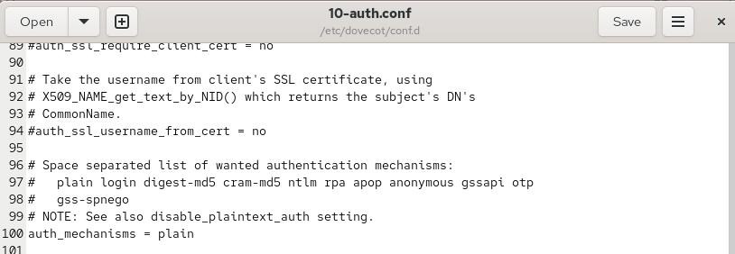

Настройка механизма аутентификации PLAIN в файле 10-auth.conf

## Настраиваю проверку паролей через PAM

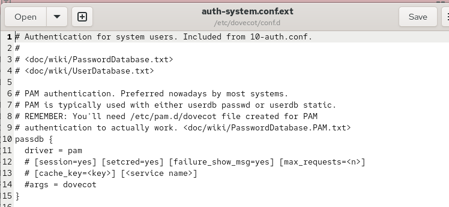

Проверка использования системного механизма PAM для аутентификации пользователей

## Настраиваю системную базу пользователей

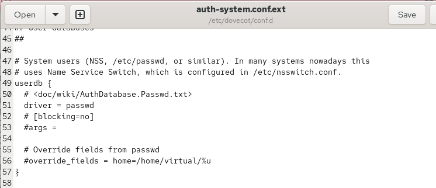

Настройка параметра userdb для получения информации о пользователях из passwd

## Указываю расположение почтовых ящиков

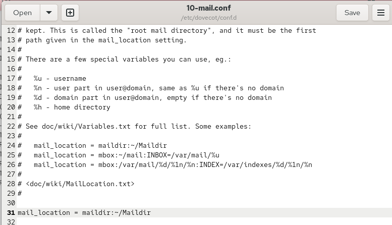

Настройка хранения сообщений в формате Maildir в файле 10-mail.conf

## Настраиваю Postfix и межсетевой экран

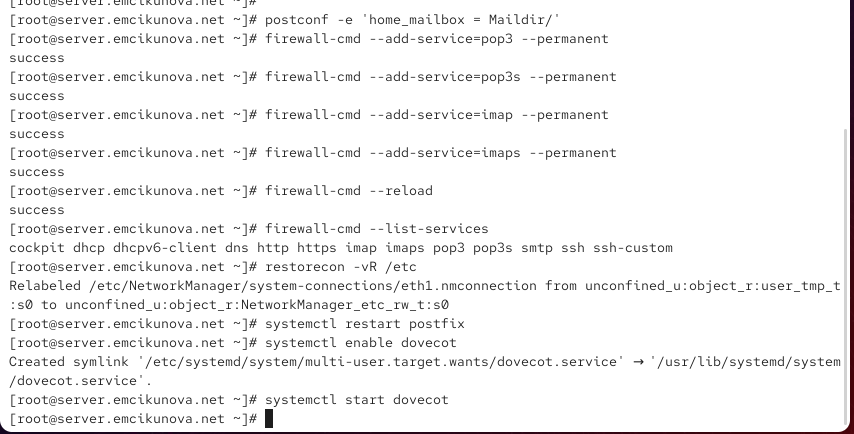

Настройка доставки почты в Maildir, разрешение протоколов POP3 и IMAP и запуск Dovecot

## Устанавливаю почтовый клиент Evolution

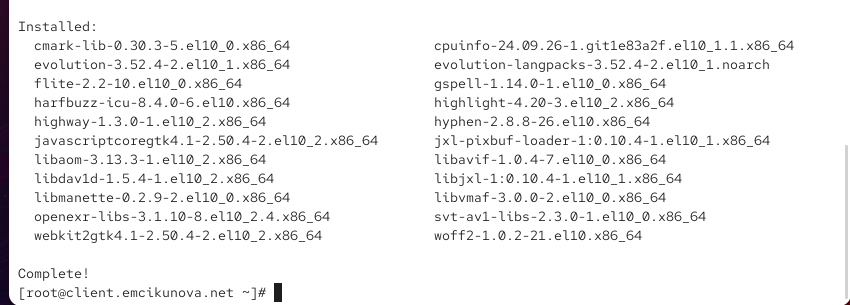

Установка Evolution на виртуальной машине client с помощью пакетного менеджера DNF

## Создаю почтовую учётную запись Evolution

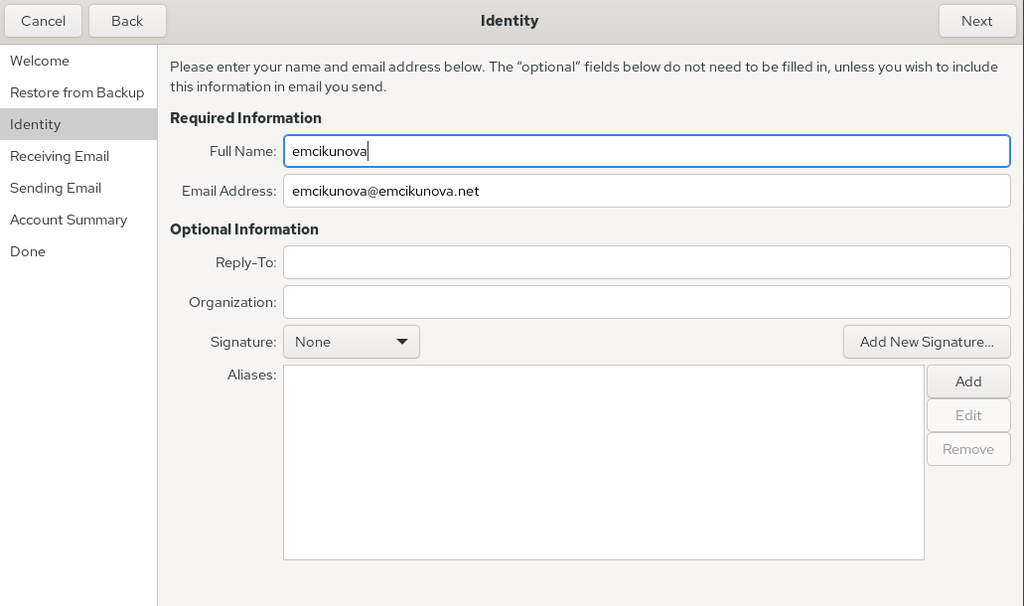

Указание имени пользователя и адреса электронной почты emcikunova@emcikunova.net

## Настраиваю получение почты по IMAP

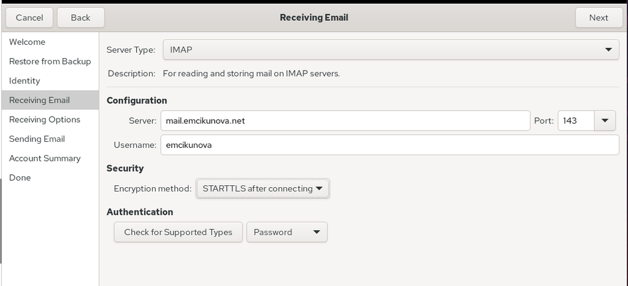

Настройка сервера mail.emcikunova.net, порта 143, шифрования STARTTLS и аутентификации по паролю

## Настраиваю отправку почты по SMTP

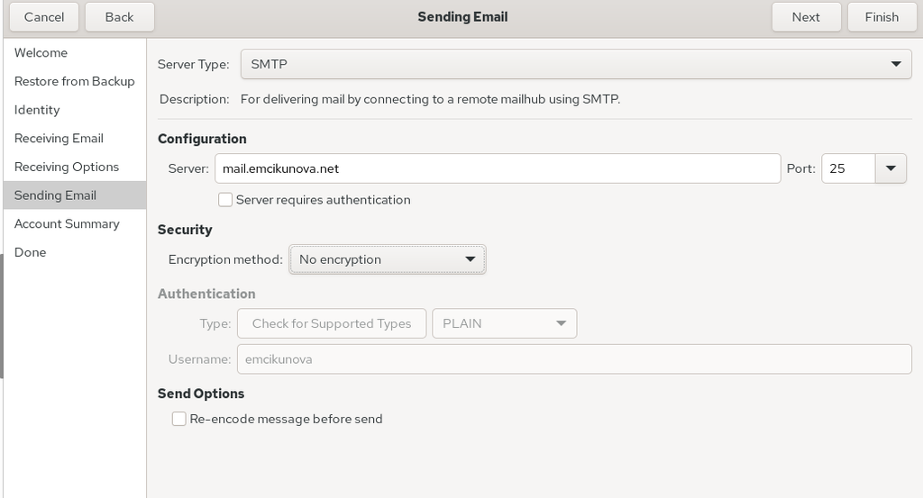

Настройка SMTP-сервера mail.emcikunova.net и порта 25 без аутентификации

## Отправляю тестовое письмо через Evolution

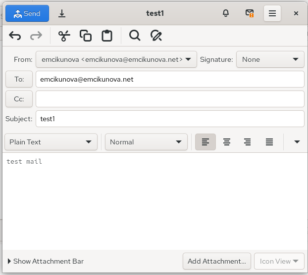

Создание и отправка тестового сообщения с темой test1 на собственный почтовый адрес

## Проверяю получение электронного письма

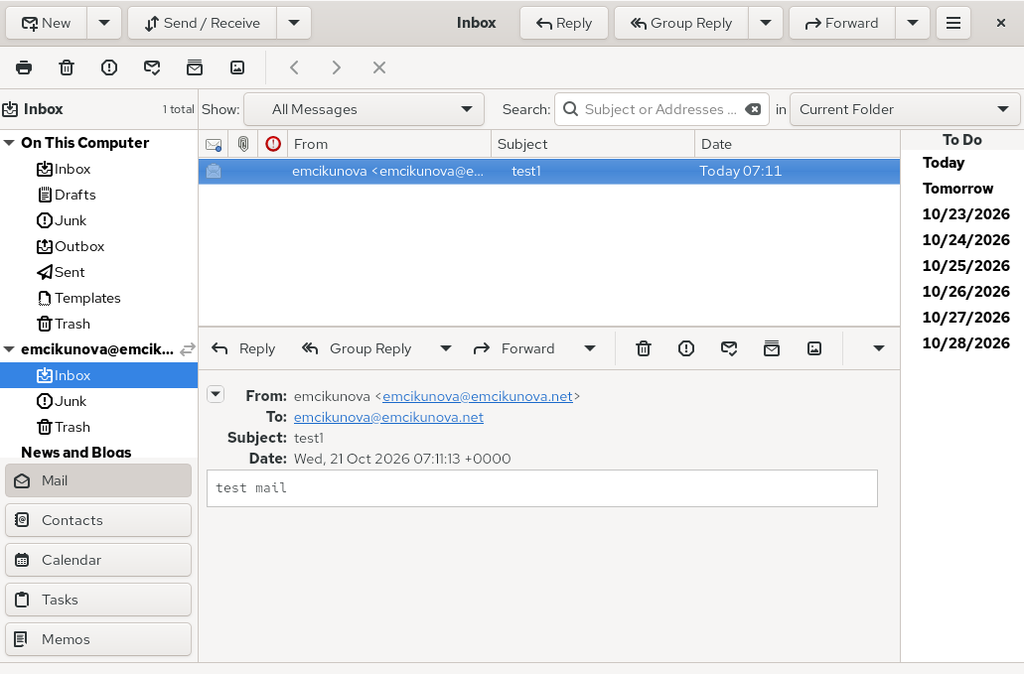

Просмотр входящего сообщения в Evolution и проверка его содержимого

## Проверяю доставку по журналу почтовой службы

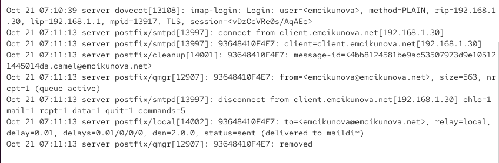

Мониторинг журнала maillog и подтверждение успешной доставки сообщения в Maildir

## Просматриваю почтовый ящик на сервере

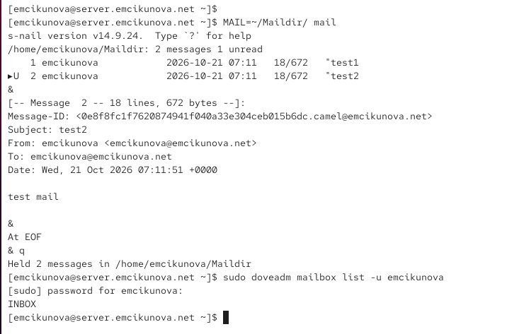

Проверка полученных сообщений с помощью mail и просмотр папок пользователя через doveadm

## Проверяю работу протокола POP3 через Telnet

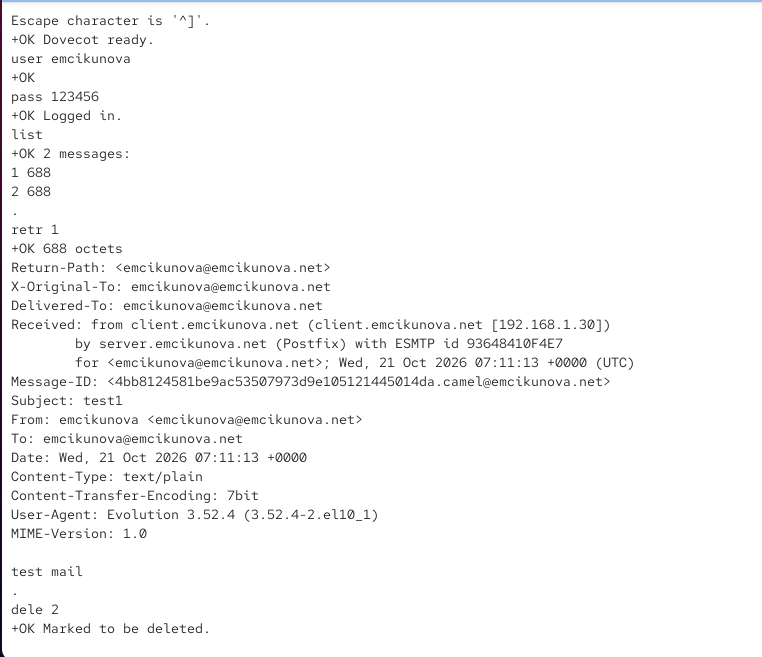

Подключение к порту 110, авторизация пользователя, просмотр писем и удаление сообщения

## Сохраняю конфигурацию Dovecot для Vagrant

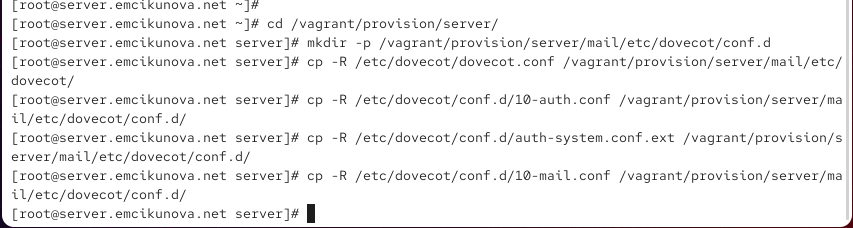

Копирование конфигурационных файлов Dovecot в каталог provision серверной виртуальной машины

## Обновляю скрипт настройки почтового сервера

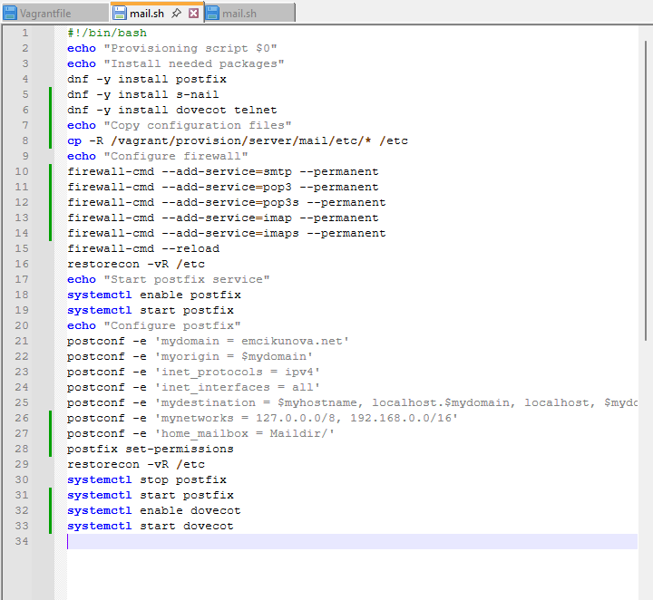

Добавление команд установки Dovecot и Telnet, настройки FirewallD и запуска служб в server/mail.sh

## Обновляю скрипт настройки клиентской машины

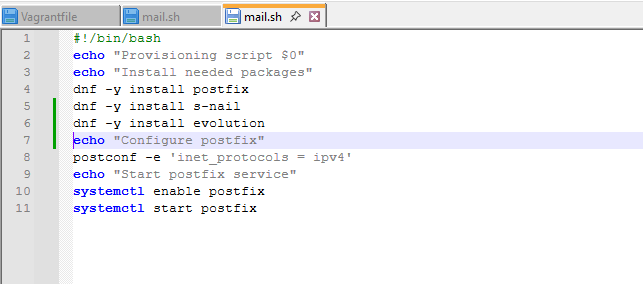

Добавление установки Evolution в скрипт provision/client/mail.sh

# Результаты лабораторной работы

## Вывод

В ходе лабораторной работы я установила и настроила почтовый сервер `Dovecot` на виртуальной машине `server`, обеспечив работу протоколов IMAP и POP3.

Настроила взаимодействие Dovecot с Postfix, хранение почтовых сообщений в формате Maildir и необходимые правила межсетевого экрана.

На виртуальной машине `client` установила и настроила почтовый клиент Evolution. Проверила отправку и получение электронных писем, работу почтовых протоколов через Telnet, а также состояние почтовых ящиков с помощью утилит `mail` и `doveadm`.

Работоспособность почтового сервера подтверждена успешной доставкой сообщений на адрес `emcikunova@emcikunova.net` и соответствующими записями в журнале `maillog`.